# Core Stats: Inference: Paired data

# Inference

## Paired Data

1. When do I perform a paired two-sample test?
2. What are the assumptions?
3. How do I interpret and present the results of the test?
4. How do I deal with paired non-normal data?

### 1. When to perform a paired two-sample test?

A paired t-test is used when we have two samples of continuous data that can be paired (examples of these sort of data would be weights of individuals before and after a diet). This test is applicable if the number of paired points within the samples is large (>30) or, if the number of points is small, then this test also works when the parent distributions are normally distributed.

Suppose we measure the cortisol levels in 20 adult females (nmol/l) first thing in the morning and again in the evening. We want to test whether the cortisol levels differ between the two measurement times. We will initially form the following null and alternative hypotheses:

$H_9$: There is no difference in cortisol level between times $(\mu M = \mu E)$ $H_1$: There is a difference in cortisol levels between times $(\mu M \neq \mu E)$

Notice we have two samples and we want to know if our data suggests that the true (ie population) means differ from one another rather than one mean specifically bigger or smaller than the other. So we use a two-tailed test. Since each data point in the first sample can be linked to another data point in the second sample by a connecting factor, we use a *paired* test. Finally, we are assuming that the parent populations are normal and have equal variance, thus we use a t-test.

Therefore, we use a two-sample, two-tailed, paired t-test to see if we can reject the null.

Let’s load up the data:

```r
cortisolDF <- read_csv("data/CS1-twopaired.csv")
head(cortisolDF)
```

| patient_id | time | cortisol |
| --- | --- | --- |
| 1 | morning | 310.6 |
| 2 | morning | 146.1 |
| 3 | morning | 297.0 |
| 4 | morning | 270.9 |
| 5 | morning | 267.5 |
| 6 | morning | 263.8 |

As before we will summarize and visualize the data first.

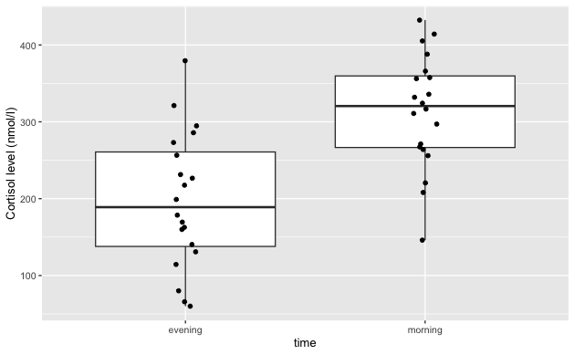

```r
ggplot(cortisolDF,
       aes(x = time, y = cortisol)) +
  geom_boxplot() +
  geom_jitter(width = 0.05) +  #we use geom_jitter instead of geom_point to add a small amount of variation in the points for better visibility and avoid overlapping points in the boxplot
  ylab("Cortisol level (nmol/l)")
```

However, we are interested in visualizing how the cortisol level of each individual subject has changed and this boxplot does not give us that information. To explore the individual changes between morning and evening we need to look at the differences between the two times of measurement for each patient. To do this, we need to put our data into a wider format. This way we can calculate the changes in the cortisol level for each patient. For this we will use the pivot_wider() function within tidyverse.

```r
cortisol_diffDF <- cortisolDF %>%
  pivot_wider(id_cols = patient_id, #says that each observational unit is determined by patient_id
              names_from = time, #says that there will be new columns with names from the 'time' column (here we only have morning and evening)
              values_from = cortisol) %>% #instruction to populate the new columns with the values coming from the 'cortisol' column
  mutate(cortisol_change = evening - morning) #create a new column called 'cortisol_change' that contains the difference between evening and morning measurements

head(cortisol_diffDF)
```

| patient_id | morning | evening | cortisol_change |
| --- | --- | --- | --- |
| 1 | 310.6 | 273.2 | -37.4 |
| 2 | 146.1 | 65.7 | -80.4 |
| 3 | 297.0 | 256.6 | -40.4 |
| 4 | 270.9 | 321.0 | 50.1 |
| 5 | 267.5 | 80.3 | -187.2 |
| 6 | 263.8 | 379.3 | 115.5 |

Lets plot this:

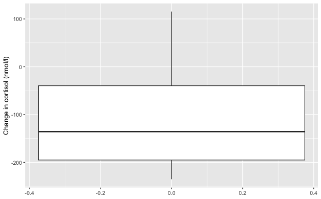

```r
ggplot(cortisol_diffDF,
       aes(y = cortisol_change)) +
  geom_boxplot() +
  ylab("Change in cortisol (nmol/l)")
```

The differences in cortisol levels appear to be very much less than zero, meaning that the evening cortisol levels appear to be much lower than the morning ones. As such we would expect that the test would give a pretty significant result.

An alternative representation would be to plot the data points for both evening and morning and connect them by patient:

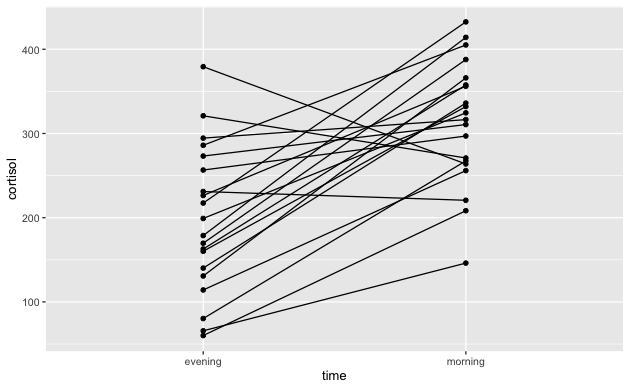

```r
ggplot(cortisolDF,
       aes(x = time,
           y = cortisol,
           group = patient_id)) +
  geom_point() +
  geom_line()
```

This gives a similar picture to what the boxplot was telling us, that for most patients the cortisol levels are higher in the morning than in the evening.

### 2. What are the assumptions?

Because we are not interested in the distributions of morning and evening cortisol levels but in the differences between the two, we need the differences between the two to be distributed normally. We can check this with Shapiro-Wilk test and Q-Q plots, using the wide data frame we created above

```r
cortisol_diffDF %>%
  pull(cortisol_change) %>%
  shapiro.test()
```

```
    Shapiro-Wilk normality test

data:  .
W = 0.92362, p-value = 0.1164
```

```r
# shapiro.test(cortisol_diffDF$cortisol_change)
```

Remember that the p-value gives the probability of observing each sample if the parent population is actually normally distributed. So here we can’t reject the null that it is normally distributed. However, also don’t forget Shapiro-Wilk test is quite sensitive to sample size. This means that if you have a large sample then even small deviations from normality will cause the sample to fail the test, whereas smaller samples are allowed to pass with much larger deviations.

Let’s look at the Q-Q plot as well:

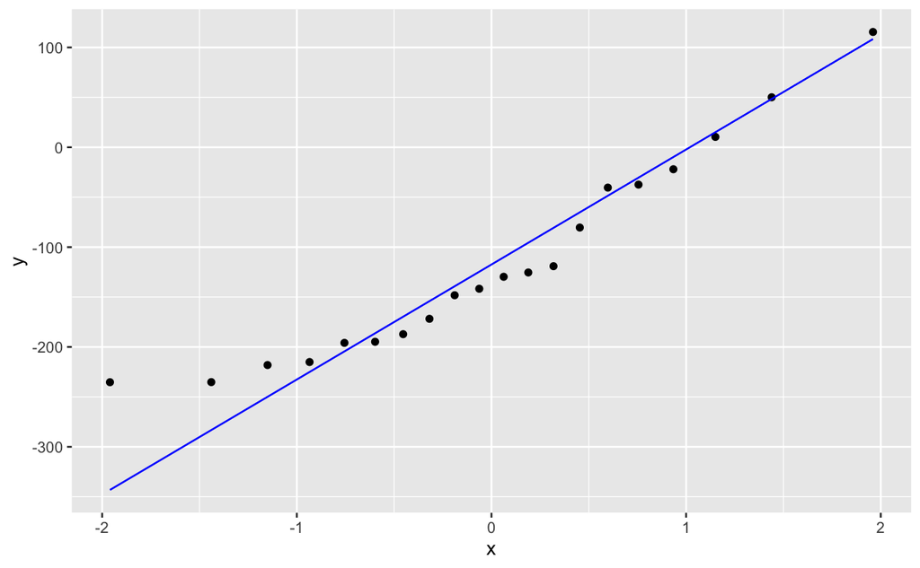

```r
cortisol_diffDF %>%
  ggplot(aes(sample = cortisol_change)) +
  stat_qq() +
  stat_qq_line(color = "blue")
```

Accordingly, we can conclude t-test is appropriate for this data set.

### 3. Two-sample, paired, two-tailed t-test

```r
t.test(cortisol ~ time,
       alternative = "two.sided",
       paired = TRUE,
       data = cortisolDF)
```

```
    Paired t-test

data:  cortisol by time
t = -5.1833, df = 19, p-value = 5.288e-05
alternative hypothesis: true mean difference is not equal to 0
95 percent confidence interval:
 -162.96038  -69.20962
sample estimates:
mean difference
       -116.085
```

### 4. Non-normal paired data

The example above assumes that the paired data come from parent distributions that are normal. As we’ve seen before, we may have data where we can’t rely on that assumption. Fortunately, there is very little that we need to change in our approach if we want to analyse paired data that violate the assumption of normality.

As with the non-normal two-sample data, there is the underlying assumption that the parent distributions of the samples are comparable in shape and variance.

The hyopthesis we are testing changes from mean difference being 0 to median difference being 0. We will use a two-tailed Wilcoxon signed rank test to see if we can reject the null hypothesis.

```r
wilcox.test(cortisol ~ time,
            alternative = "two.sided",
            paired = TRUE,
            data = cortisolDF)
```

```
    Wilcoxon signed rank exact test

data:  cortisol by time
V = 13, p-value = 0.0001678
alternative hypothesis: true location shift is not equal to 0
```

Again the p-value is coniderably less than 0.01, so we can reject the null hypothesis and conclude: “A two-tailed Wilcoxon signed rank test indicated that the median cortisol level in adult females different significantly between the morning (320.5 nmol/l) and the evening (188.9 nmol/l, p=0.00017).”

### Summary

Paired t-tests are used when you have two paired samples of continuous data, which are normally distributed and have equal variance A good way of assessing the assumption of normality is by checking the data against a Q-Q plot We can check equality of variance (homoscedasticity) with Bartlett’s (normal data) or Levene’s (non-normal data) test The Wilcoxon signed rank test is used when you have two paired samples of continuous data, which are not normally distributed (but have comparable distributional shapes), and have equal variance.